# Homework3

Klaudia Magda

11 listopada 2016

# Libraries

```r
library(e1071)
library(caret)
library(magrittr)
library(plyr)
library(dplyr)
library(corrplot)
library(randomForest)
library(pROC)
library(Epi)
library(nnet)
library(party)
library(rpart)
```

## Load dataStudent

```r
data<-read.csv(file="student-mat.csv", sep=";")
```

## Preprocessing

Preprocessing will help us to reduce amount of predictors. Chosen methods: Removing near zero variance variables (if exists), normalisation and removing highly correlated variables

```r
#Removing near zero variance variables
nzv <- nearZeroVar(data)
names(data)[nzv]
```

```
## character(0)
```

```r
#Normalisation
preProcValues <- preProcess(data, method = c("range"))
dataNorm <- predict(preProcValues, data)
#Removing highly correlated variables
d.num <- dataNorm %>% select(which(sapply(dataNorm, is.numeric)))
too_high <- findCorrelation(cor(d.num), cutoff = 0.725, verbose = FALSE)
names(d.num)[too_high]
```

```
## [1] "G2" "G1"
```

```r
data = dataNorm[,-c(too_high)]
```

# Feature selection

After data preparation there is a need to choose only the best variables for classification. decided to use a `filter` method - Selection by filter (`sbf`) on a smaller sample of the dataset to receive higher accuracy (for bigger dataset accuracy is very low).

We can notice that the best variables to classifiers are correlated G1 and G2.

```r
size <- floor(0.05 * nrow(data))
indxSample <- sample(seq_len(nrow(data)), size = size)
dataSmall <- data[indxSample, ]
length(levels(dataSmall$Class))
```

```
## [1] 0
```

```r
length(levels(dataSmall$G3))
```

```
## [1] 0
```

```r
#SBF
filterCtrl <- sbfControl(functions = rfSBF, method = "repeatedcv", verbose = FALSE, repeats = 5)
rfWithFilter <- sbf(form = G3 ~ ., data = dataSmall, sbfControl = filterCtrl, allowParallel = TRUE, variables=TRUE)
rfWithFilter
```

```
##
## Selection By Filter
##
## Outer resampling method: Cross-Validated (10 fold, repeated 5 times)
##
## Resampling performance:
##
##    RMSE Rsquared RMSESD RsquaredSD
##  0.1728        1 0.1093          0
##
## Using the training set, 2 variables were selected:
##    G1, G2.
##
## During resampling, the top 5 selected variables (out of a possible 8):
##    G1 (100%), G2 (100%), reasonreputation (10%), famsizeLE3 (6%), Fjobservices (4%)
##
## On average, 2.3 variables were selected (min = 2, max = 4)
```

# Division

Division is made 75:25

```r
set.seed(1313)
size <- floor(0.75 * nrow(dataSmall))
indxTrain <- sample(seq_len(nrow(dataSmall)), size = size)

dataSmallTrain <- dataSmall[indxTrain, ]
dataSmallTest <- dataSmall[-indxTrain, ]
```

# Forest

Forest is a set of multiple amount of trees. Here -> for every variable

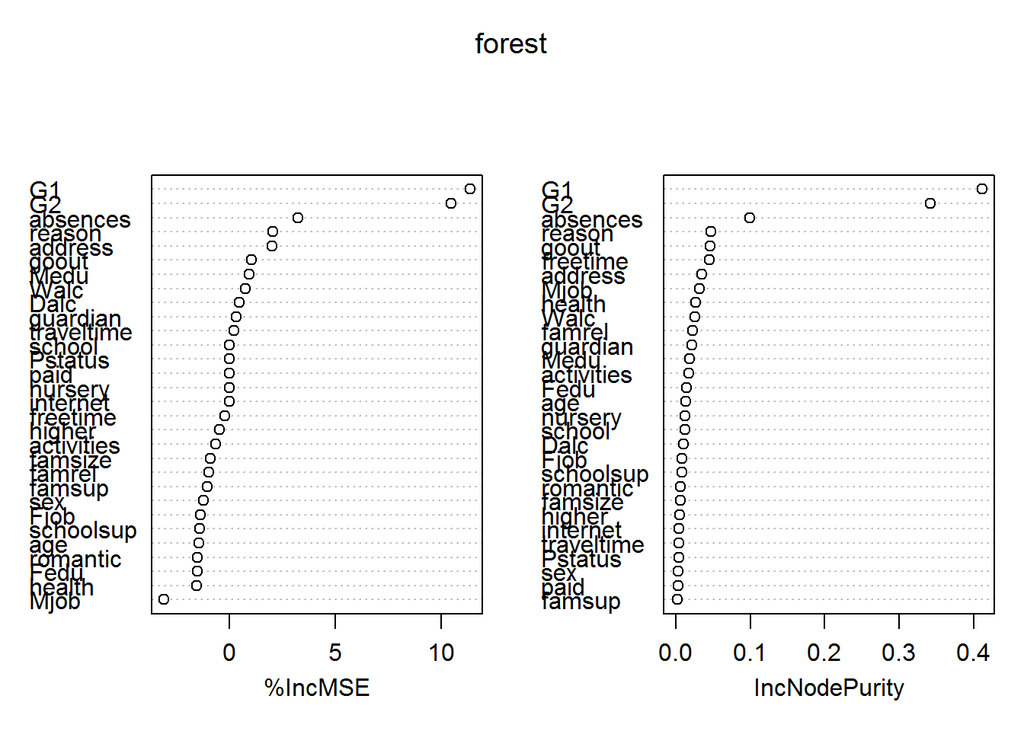

```r
forest <- randomForest(G3 ~ ., data = dataSmallTrain, importance = TRUE, na.action = na.omit)
varImpPlot(forest)
```

```r
importance(forest)
```

```
##               %IncMSE IncNodePurity
## school      0.0000000   0.011819506
## sex        -1.2053016   0.002876087
## age        -1.4088255   0.013282706
## address     2.0285438   0.034673337
## famsize    -0.8876981   0.005563017
## Pstatus     0.0000000   0.003535228
## Medu        0.9433017   0.018009044
## Fedu       -1.4962664   0.013723635
## Mjob       -3.0649925   0.031924280
## Fjob       -1.3430154   0.008470701
## reason      2.0623451   0.047174704
## guardian    0.3574164   0.020870557
## traveltime  0.2164090   0.003719615
## schoolsup  -1.3973008   0.008437321
## famsup     -1.0307886   0.002045733
## paid        0.0000000   0.002742639
## activities -0.6324958   0.017376421
## nursery     0.0000000   0.011919909
## higher     -0.4539786   0.004546231
## internet    0.0000000   0.004020099
## romantic   -1.4757437   0.006361525
## famrel     -0.9569055   0.022168170
## freetime   -0.1949460   0.044646165
## goout       1.0452815   0.046072314
## Dalc        0.4664173   0.010004595
## Walc        0.7626120   0.025129127
## health     -1.5353526   0.026318546
## absences    3.2317482   0.099692727
## G1         11.3669421   0.411649914
## G2         10.4794352   0.342384947
```

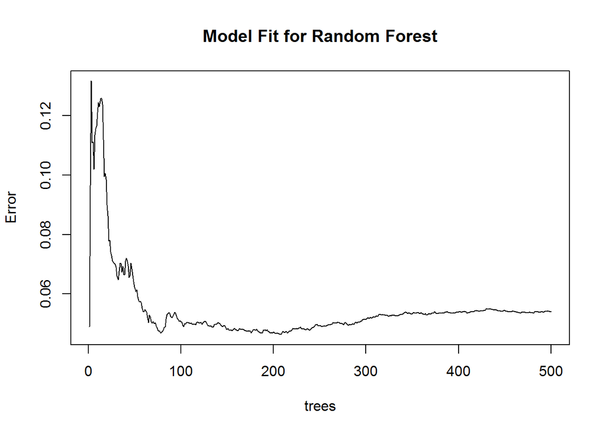

```r
predForest = predict(forest, dataSmallTest, type="class")
plot(forest, main="Model Fit for Random Forest")
```

```r
forestTab <- table(true = dataSmallTest$G3, predicted = predForest)
rfAcc <- sum(diag(forestTab)) / sum(forestTab)
rfAcc
```

```
## [1] 0.2
```

# Top Variables

According to results of filtering, it is sufficient to make classification based on 2 top variables. G1 G2

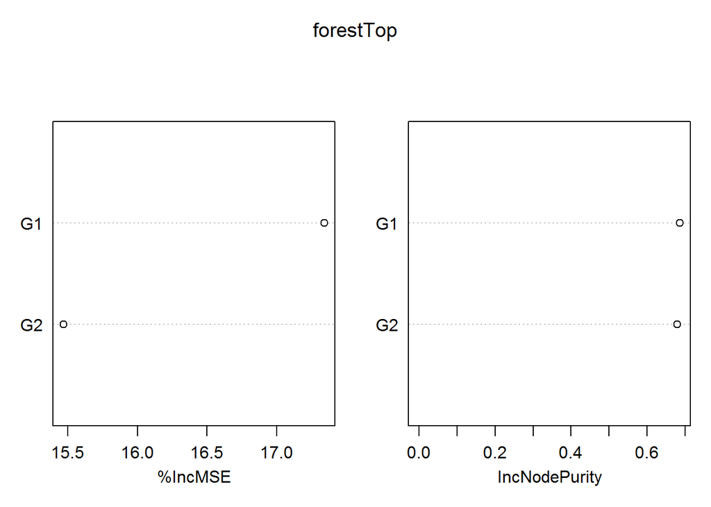

```r
forestTop <- randomForest(G3 ~ G1 + G2, data = dataSmallTrain, importance = TRUE, na.action = na.omit)
varImpPlot(forestTop)
```

```r
importance(forestTop)
```

```
##     %IncMSE IncNodePurity
## G1 17.34193     0.6863805
## G2 15.47021     0.6783179
```

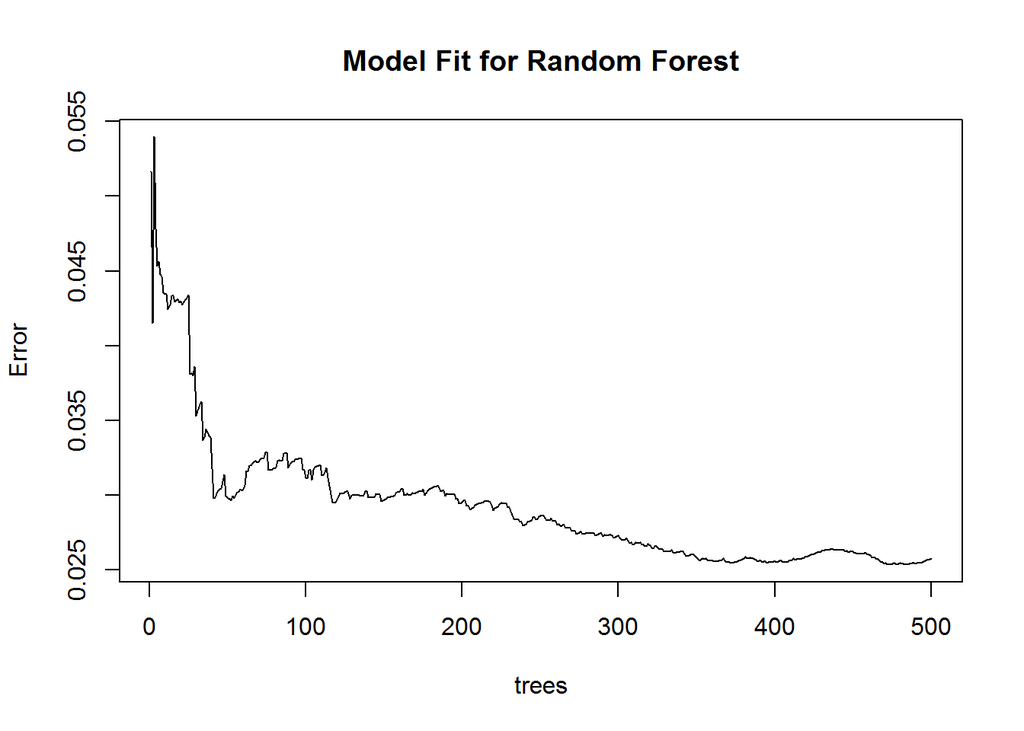

```r
predForestTop = predict(forestTop, dataSmallTest, type="class")
plot(forestTop, main="Model Fit for Random Forest")
```

```r
forestTopTab <- table(true = dataSmallTest$G3, predicted = predForestTop)
rfTopAcc <- sum(diag(forestTopTab)) / sum(forestTopTab)
rfTopAcc
```

```
## [1] 0
```

## Tree

Tree is undirected graph with nodes and leaf nodes that can indicate the value of Class.

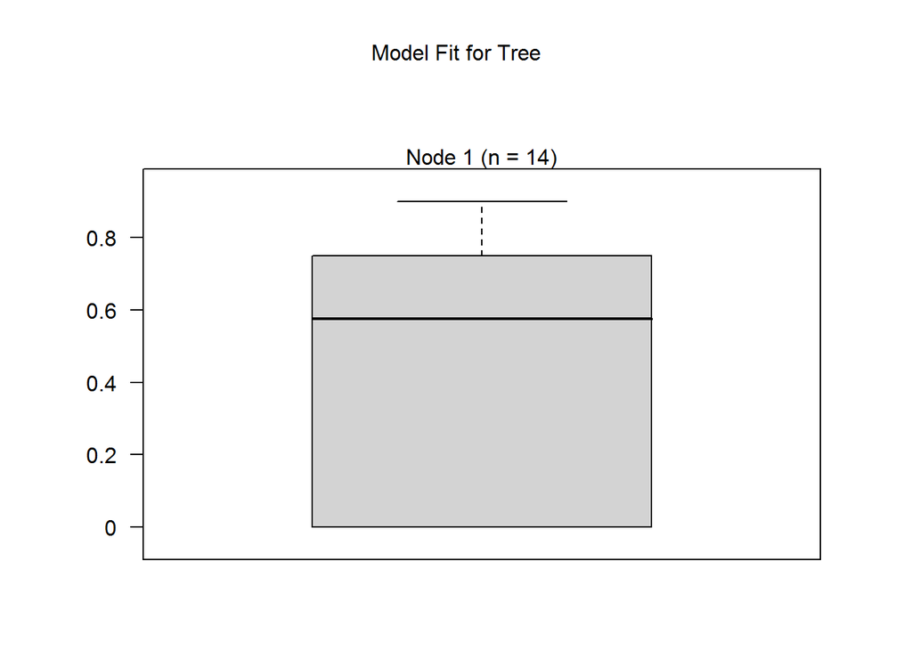

```r
tree<-ctree(G3 ~ ., data=dataSmallTrain)
predTree = predict(tree, dataSmallTest)
plot(tree, main="Model Fit for Tree")
```

```r
treeTab <- table(true = dataSmallTest$G3, predicted = predTree)
treeAcc <- sum(diag(treeTab)) / sum(treeTab)
treeAcc
```

```
## [1] 0.2
```

## Tree

Tree for TopVariables

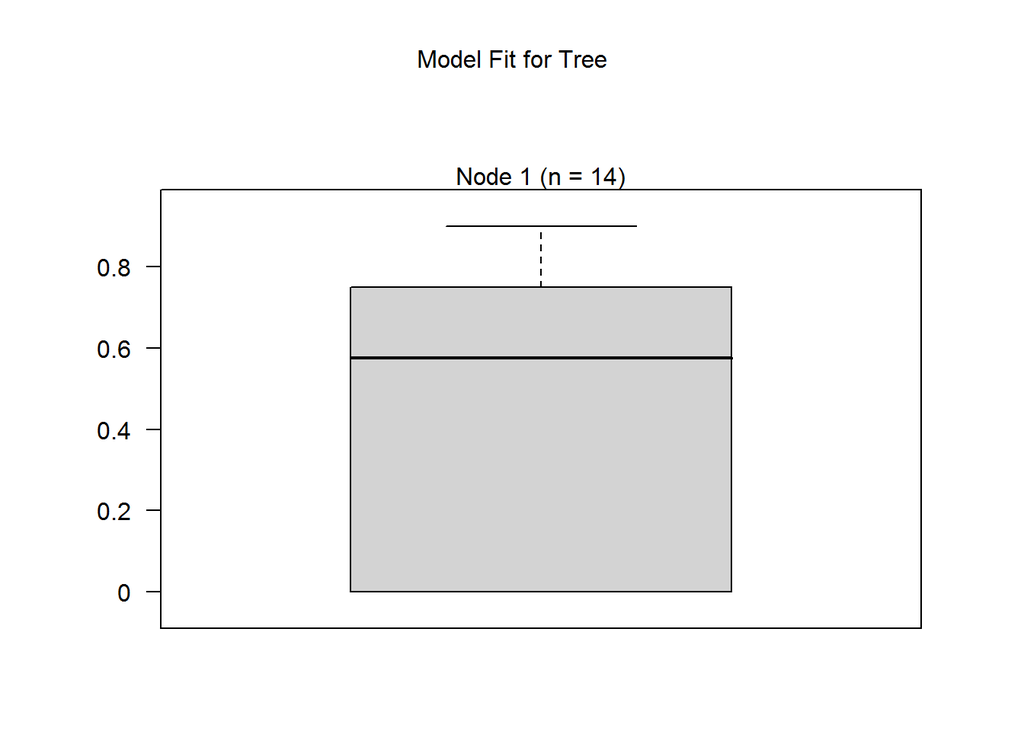

```r
treeTop<-ctree(G3 ~ G1 + G2, data=dataSmallTrain)
predTreeTop = predict(treeTop, dataSmallTest)
plot(treeTop, main="Model Fit for Tree")
```

```r
treeTabTop <- table(true = dataSmallTest$G3, predicted = predTreeTop)
treeTopAcc <- sum(diag(treeTabTop)) / sum(treeTabTop)
treeTopAcc
```

```
## [1] 0.2
```

# Conclusions

```
##         Accuracy
## RF           0.2
## RFTOP        0.0
## TREE         0.2
## TREETOP      0.2
```